# Herrings

2022-12-08

# Summary

Source data contained not many NA values. Based on initial processing years were assumed from `totaln` and position in source. Records were aggregated to the level of separate months each value being the mean of aggregated rows.

Such data showed noticeable linear correlation across groups of catch measures (`fbar`, `recr`,`cumf`, `totaln`) and plankton amount (`cfin1`, `cfin2`, `chel1`, `chel2`,`clop1`, `clop2`) and between `length`, `sst` and time.

Constructed regression model showed that the most significant for the `length` of herrings were

- local catch intensity
- total number of herrings catched
- sea surface temperature

Based on the distribution of these measures, it can be concluded that crucial influence on decrease in herrings length over last years had increase in sea surface temperature.

# Load data

```
## # A tibble: 52,582 × 16
##    month row_id length  cfin1 cfin2 chel1 chel2 lcop1 lcop2  fbar   recr  cumf
##    <int>  <int>  <dbl>  <dbl> <dbl> <dbl> <dbl> <dbl> <dbl> <dbl>  <int> <dbl>
##  1     7      0   23   0.0278 0.278  2.47  NA    2.55  26.4 0.356 482831 0.306
##  2     7      1   22.5 0.0278 0.278  2.47  21.4  2.55  26.4 0.356 482831 0.306
##  3     7      2   25   0.0278 0.278  2.47  21.4  2.55  26.4 0.356 482831 0.306
##  4     7      3   25.5 0.0278 0.278  2.47  21.4  2.55  26.4 0.356 482831 0.306
##  5     7      4   24   0.0278 0.278  2.47  21.4  2.55  26.4 0.356 482831 0.306
##  6     7      5   22   0.0278 0.278  2.47  21.4  2.55  NA   0.356 482831 0.306
##  7     7      6   24   0.0278 0.278  2.47  21.4  2.55  26.4 0.356 482831 0.306
##  8     7      7   23.5 0.0278 0.278  2.47  21.4  2.55  26.4 0.356 482831 0.306
##  9     7      8   22.5 0.0278 0.278  2.47  21.4  2.55  26.4 0.356 482831 0.306
## 10     7      9   22.5 0.0278 0.278  2.47  21.4  2.55  26.4 0.356 482831 0.306
## # … with 52,572 more rows, and 4 more variables: totaln <dbl>, sst <dbl>,
## #   sal <dbl>, nao <dbl>
```

Loaded 52582 rows with 16 columns from source.

## NA values in each column

| month | row_id | length | cfin1 | cfin2 | chel1 | chel2 | lcop1 | lcop2 | fbar | recr | cumf | totaln | sst | sal | nao | Total |
| --- | --- | --- | --- | --- | --- | --- | --- | --- | --- | --- | --- | --- | --- | --- | --- | --- |
| 0 | 0 | 0 | 1581 | 1536 | 1555 | 1556 | 1653 | 1591 | 0 | 0 | 0 | 0 | 1584 | 0 | 0 | 11056 |

## Distinct values in each column

| month | row_id | length | cfin1 | cfin2 | chel1 | chel2 | lcop1 | lcop2 | fbar | recr | cumf | totaln | sst | sal | nao |
| --- | --- | --- | --- | --- | --- | --- | --- | --- | --- | --- | --- | --- | --- | --- | --- |
| 12 | 52582 | 59 | 40 | 49 | 49 | 52 | 49 | 52 | 51 | 52 | 52 | 53 | 52 | 51 | 45 |

## Test grouping years by totaln

| across each distinct month | row_id | length | cfin1 | cfin2 | chel1 | chel2 | lcop1 | lcop2 | fbar | recr | cumf | sst | sal | nao |
| --- | --- | --- | --- | --- | --- | --- | --- | --- | --- | --- | --- | --- | --- | --- |
| distinct values | [1-1170] | [1-45] | [1-11] | [1-4] | [1-12] | [1-3] | [1-12] | [1-4] | [1-1] | [1-1] | [1-1] | [1-3] | [1-3] | [1-7] |
| -//- no NA rows | [1-959] | [1-39] | [1-10] | [1-3] | [1-11] | [1-3] | [1-11] | [1-3] | [1-1] | [1-1] | [1-1] | [1-3] | [1-3] | [1-7] |
| NA values | [0-0] | [0-0] | [0-30] | [0-35] | [0-33] | [0-35] | [0-35] | [0-28] | [0-0] | [0-0] | [0-0] | [0-29] | [0-0] | [0-0] |
| not NA values | [1-1170] | [1-1170] | [1-1140] | [1-1135] | [1-1137] | [1-1135] | [1-1135] | [1-1142] | [1-1170] | [1-1170] | [1-1170] | [1-1141] | [1-1170] | [1-1170] |

# Processing

Based on the data assumed that

- years result from unique values of totaln (equivalent to `fbar`, `recr`, `cumf`, due to only one distinct value for each group)
- following years derieved from average row id

## Data distribution

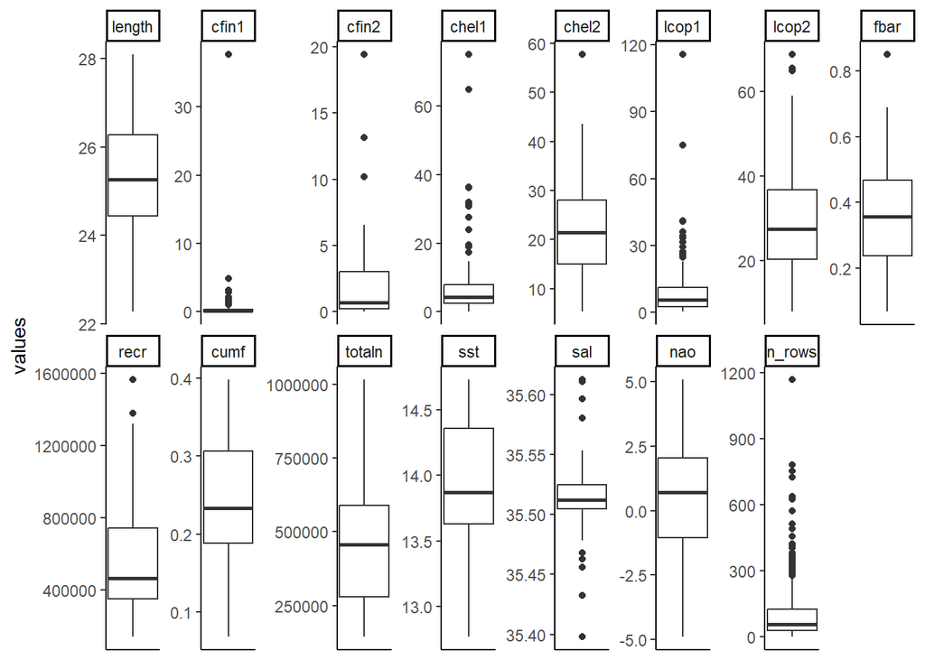

## Correlation

### Pearson

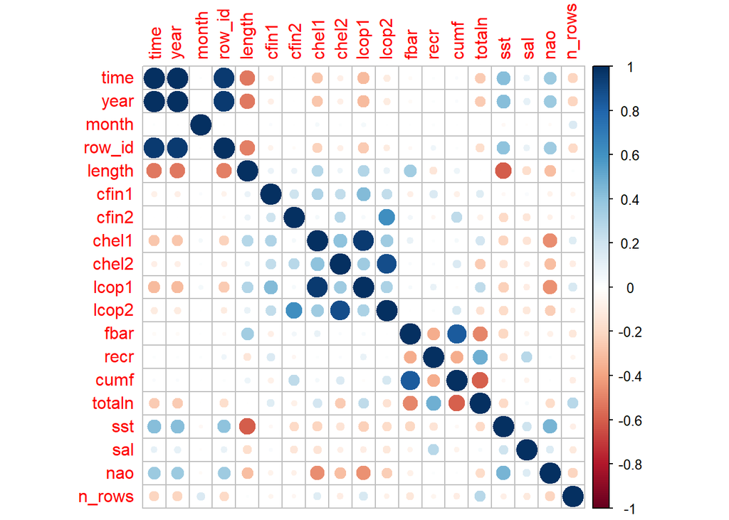

### Kendall

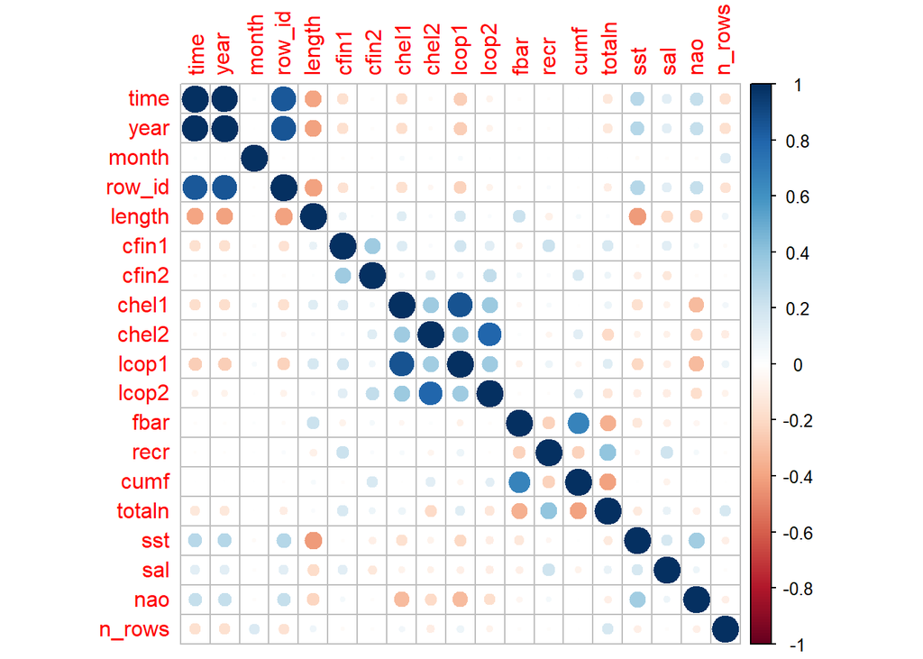

### Spearman

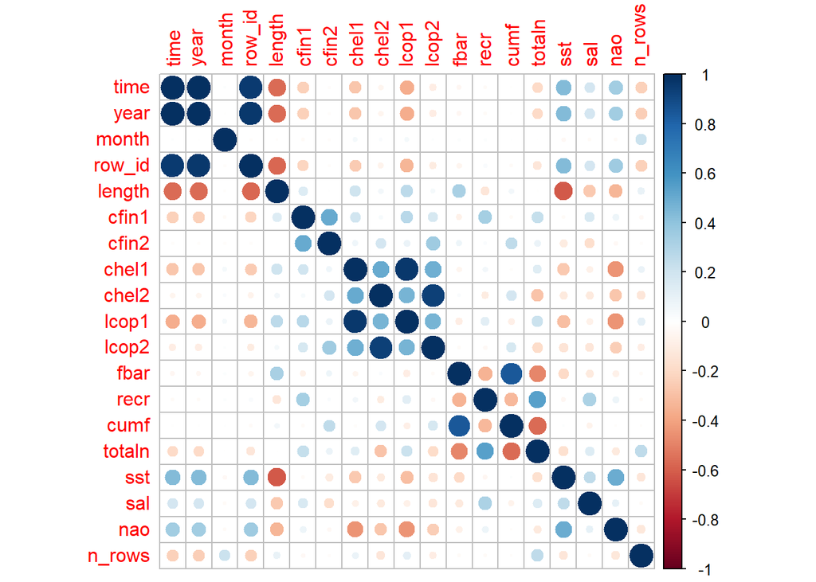

Visible correlation groups and

- `fbar`, `recr`,`cumf`, `totaln`
- `length` and time measures
- `sst`, `length`
- `cfin1`, `cfin2`
- `chel1`, `chel2`,`clop1`, `clop2`
- `nao` with different measures (`chel1`, `clop1`, `sst`)

## Herring length over years

### All observations

[figure not shown]

### All vs. >50

Number of records influence on results

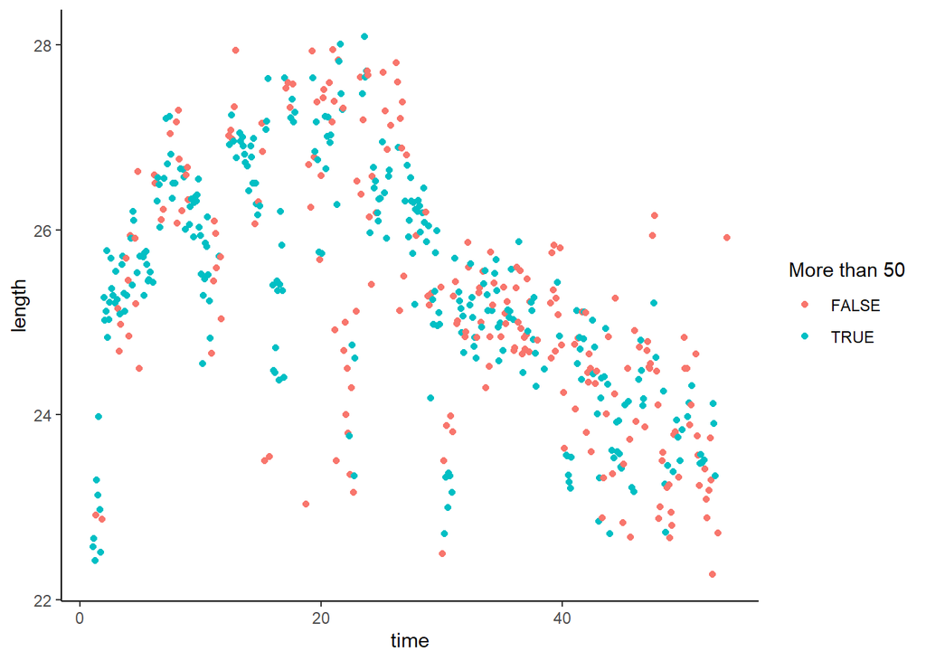

# Regression model

## Predicted model

```
## Generalized Linear Model
##
## 397 samples
##  18 predictor
##
## Pre-processing: scaled (18), centered (18)
## Resampling: Cross-Validated (10 fold, repeated 10 times)
## Summary of sample sizes: 357, 357, 357, 358, 357, 357, ...
## Resampling results:
##
##   RMSE       Rsquared   MAE
##   0.8361064  0.6087899  0.6582521
```

## Variables importance

Importance of each variable in predicted model

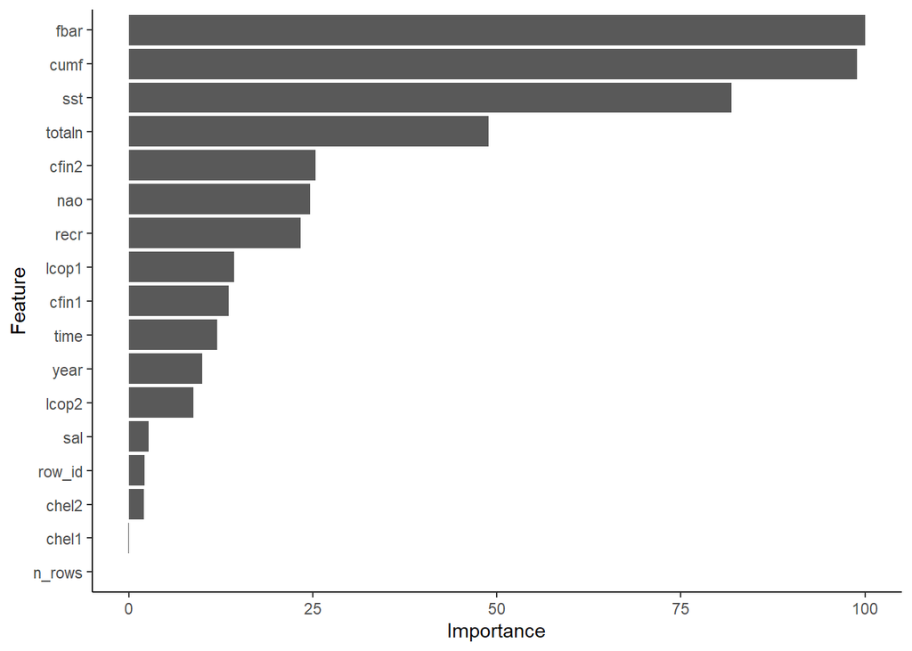

Most significant measures are:

- `cumf`
- `fbar`
- `sst`
- `totaln`

Their distribution over time:

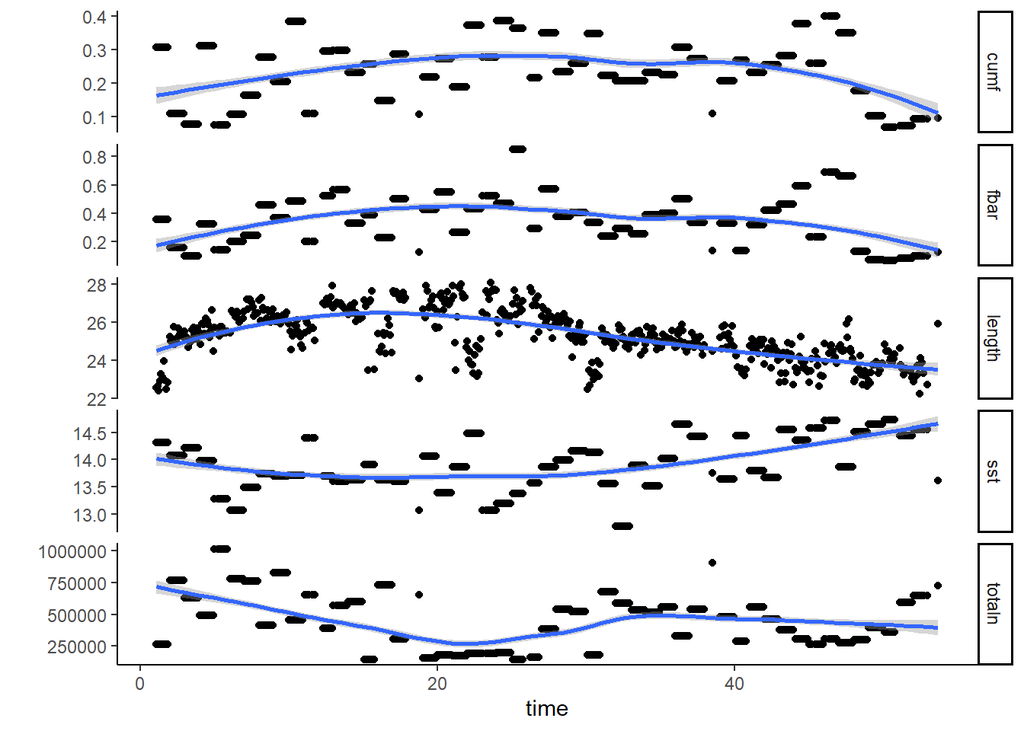

## Prediction measures on testing set

```
##      RMSE  Rsquared       MAE
## 0.7767634 0.6482214 0.5837056
```

## Predicted model

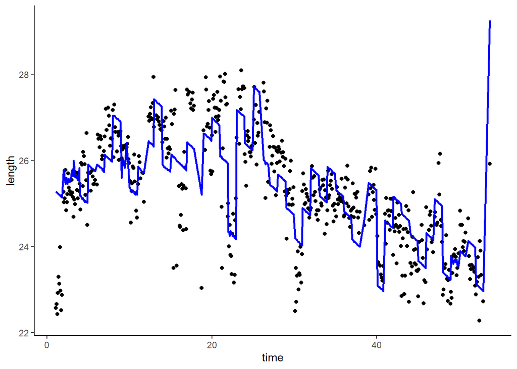